# Reproducible Research Peer Assessment 2

Pauleen Teoh

27/08/2020

## Introduction

Storms and other severe weather events can cause both public health and economic problems for communities and municipalities. Many severe events can result in fatalities, injuries, and property damage, and preventing such outcomes to the extent possible is a key concern.

This project involves exploring the U.S. National Oceanic and Atmospheric Administration’s (NOAA) storm database. This database tracks characteristics of major storms and weather events in the United States, including when and where they occur, as well as estimates of any fatalities, injuries, and property damage.

## Data

The data for this assignment come in the form of a comma-separated-value file compressed via the bzip2 algorithm to reduce its size. Download url: https://d396qusza40orc.cloudfront.net/repdata%2Fdata%2FStormData.csv.bz2

## Data Processing

```r
storm_bz2_file <- "storm.csv.bz2"

# Check if archive already exists.
if(!file.exists(storm_bz2_file)){
    file_url <- "https://d396qusza40orc.cloudfront.net/repdata%2Fdata%2FStormData.csv.bz2"
    download.file(file_url, storm_bz2_file, method="curl")
}

# read data from storm_bz2_file into storm_df data frame
storm_df <- read.csv(storm_bz2_file)

# only read variables relevant this assignment
storm_df <- storm_df[ , c("EVTYPE", "FATALITIES", "INJURIES", "PROPDMG", "PROPDMGEXP", "CROPDMG", "CROPDMGEXP")]

# change all event names to upper case for more accurate processing
storm_df$EVTYPE <- toupper(storm_df$EVTYPE)
storm_df$PROPDMGEXP <- toupper(storm_df$PROPDMGEXP)
storm_df$CROPDMGEXP <- toupper(storm_df$CROPDMGEXP)

# check no. of observations and variables
str(storm_df)
```

```
## 'data.frame':    902297 obs. of  7 variables:
##  $ EVTYPE    : chr  "TORNADO" "TORNADO" "TORNADO" "TORNADO" ...
##  $ FATALITIES: num  0 0 0 0 0 0 0 0 1 0 ...
##  $ INJURIES  : num  15 0 2 2 2 6 1 0 14 0 ...
##  $ PROPDMG   : num  25 2.5 25 2.5 2.5 2.5 2.5 2.5 25 25 ...
##  $ PROPDMGEXP: chr  "K" "K" "K" "K" ...
##  $ CROPDMG   : num  0 0 0 0 0 0 0 0 0 0 ...
##  $ CROPDMGEXP: chr  "" "" "" "" ...
```

## Goal of Assignment

The basic goal of this assignment is to explore the NOAA Storm Database and answer some basic questions about severe weather events.

## Results

1. Across the United States, which types of events (as indicated in the EVTYPE variable) are most harmful with respect to population health?

```r
fatality <- tapply(storm_df$FATALITIES, storm_df$EVTYPE, sum)
fatality <- sort(fatality, decreasing = TRUE)

# check most harmful events (fatality) before plot the barchart
head(fatality)
```

```
##        TORNADO EXCESSIVE HEAT    FLASH FLOOD           HEAT      LIGHTNING
##           5633           1903            978            937            816
##      TSTM WIND
##            504
```

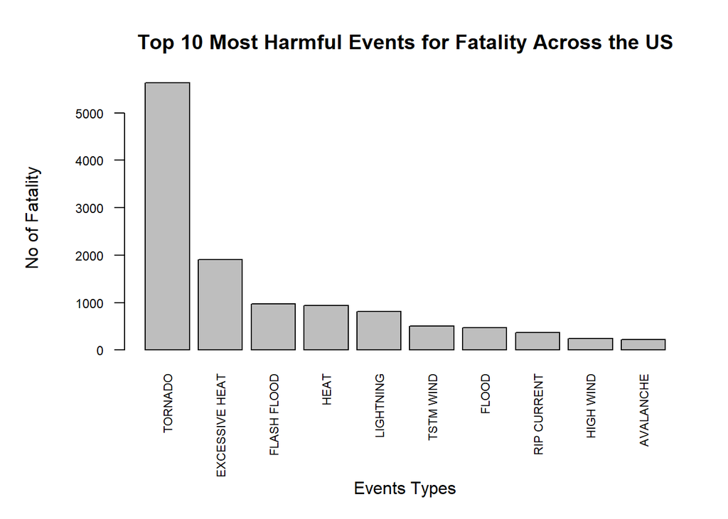

```r
par(mar=c(8,6,4,2))

# Top 10 most harmful events for fatality
barplot(height = fatality[1:10], cex.axis = 0.75, cex.name = 0.7, las = 2, main = "Top 10 Most Harmful Events for Fatality Across the US")
mtext(text = "Events Types",side =1, line = 6)
mtext(text = "No of Fatality", side = 2, line = 4)
```

```r
injury <- tapply(storm_df$INJURIES, storm_df$EVTYPE, sum)
injury <- sort(injury, decreasing = TRUE)

# check most harmful events (injury) before plot the barchart
head(injury)
```

```
##        TORNADO      TSTM WIND          FLOOD EXCESSIVE HEAT      LIGHTNING
##          91346           6957           6789           6525           5230
##           HEAT
##           2100
```

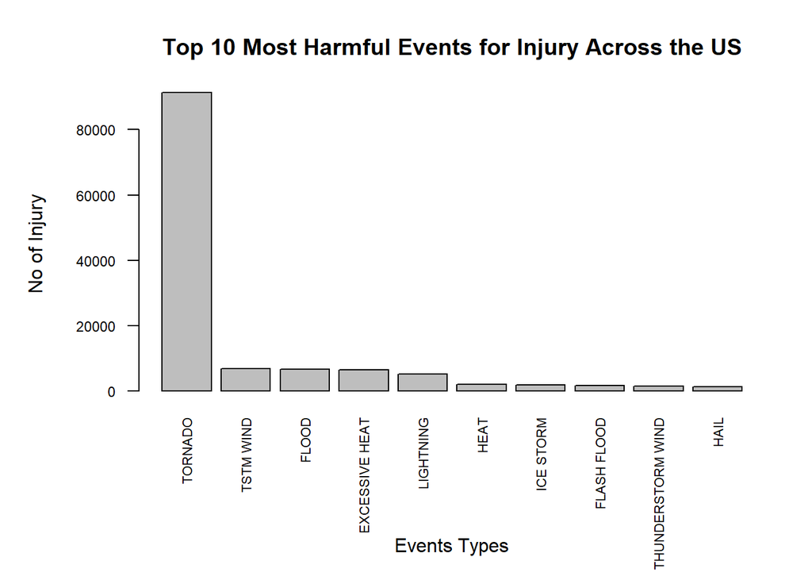

```r
par(mar=c(8,6,4,2))

# Top 10 most harmful events for injury
barplot(height = injury[1:10], cex.axis = 0.75, cex.name = 0.7, las = 2, main = "Top 10 Most Harmful Events for Injury Across the US")
mtext(text = "Events Types",side =1, line = 6)
mtext(text = "No of Injury", side = 2, line = 4)
```

Top 10 most harmful events for both fatality and injury are shown in their respective bar chart.